# R Language for Biological Data Analysis

Session 1.2 : Innovating Product using Statistics

Muhammad Naufal Hakim

2026-08-26

# 1 Welcome

This document is your workbook for Session 1.2. It mixes explanation with figure and code that you can run yourself — click the green ▶ button (top-right of each grey box) or press `Ctrl+Enter` / `Cmd+Enter` with your cursor on a line to run it.

# 2 Help me! BoD are waiting for my result!

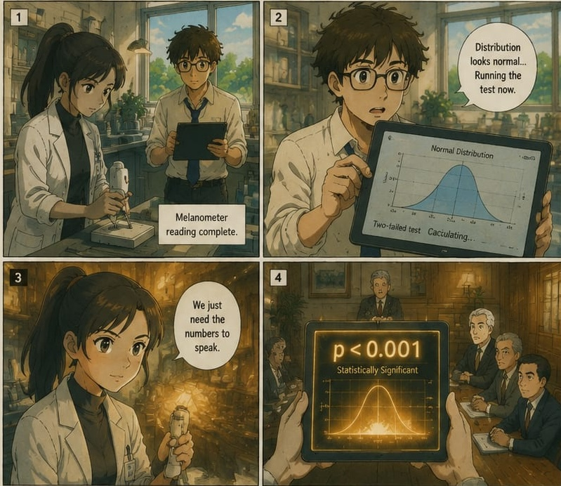

Study Case

**Before you start:**

Run the setup chunk below first — everything depends on it.

```r
library(readr)
library(dplyr)
library(ggplot2)
library(tidyr)
library(readxl)
library(qqman)
```

If that chunk errors with `there is no package called ...`, run this once in the Console (not in this file), then re-run the chunk above:

```r
install.packages(c("readr", "dplyr", "ggplot2", "tidyr", "qqman", "readxl"))
```

# 3 Data Import and Manipulation

You will find `measurement.txt` and `measurement.xlsx` in the folder. Import them to the folder using these command :

```r
measurement_txt    <- read.delim("/Users/hakimbazol/Documents/03_projects/r_for_biological_data_analysis/session1/measurement.txt", check.names = F)
measurement_xlsx   <- read_excel("/Users/hakimbazol/Documents/03_projects/r_for_biological_data_analysis/session1/measurement.xlsx")
```

Check class of data :

```r
class(measurement_txt)      # Get data type
```

```
## [1] "data.frame"
```

Using these command to inspect data:

```r
dim(measurement_txt)      # Get dimension of data
```

```
## [1] 30  2
```

```r
str(measurement_txt)      # Get dimension of data, together with the column names
```

```
## 'data.frame':    30 obs. of  2 variables:
##  $ Baseline        : num  353 234 278 297 252 ...
##  $ After Four Weeks: num  309 231 274 267 227 ...
```

```r
head(measurement_txt)     # Get the column together with first six rows (default)
```

```
##   Baseline After Four Weeks
## 1 353.3333         309.0000
## 2 233.6667         230.6667
## 3 277.6667         274.3333
## 4 297.0000         266.6667
## 5 252.3333         227.0000
## 6 243.3333         236.0000
```

```r
summary(measurement_txt)  # Get the statistical summary of each column data
```

```
##     Baseline     After Four Weeks
##  Min.   :225.0   Min.   :215.0
##  1st Qu.:268.5   1st Qu.:249.5
##  Median :294.3   Median :280.8
##  Mean   :294.8   Mean   :280.4
##  3rd Qu.:311.9   3rd Qu.:297.3
##  Max.   :413.0   Max.   :384.7
```

R has two kind of data format, which is called as long and wide data. You can see the different format below :

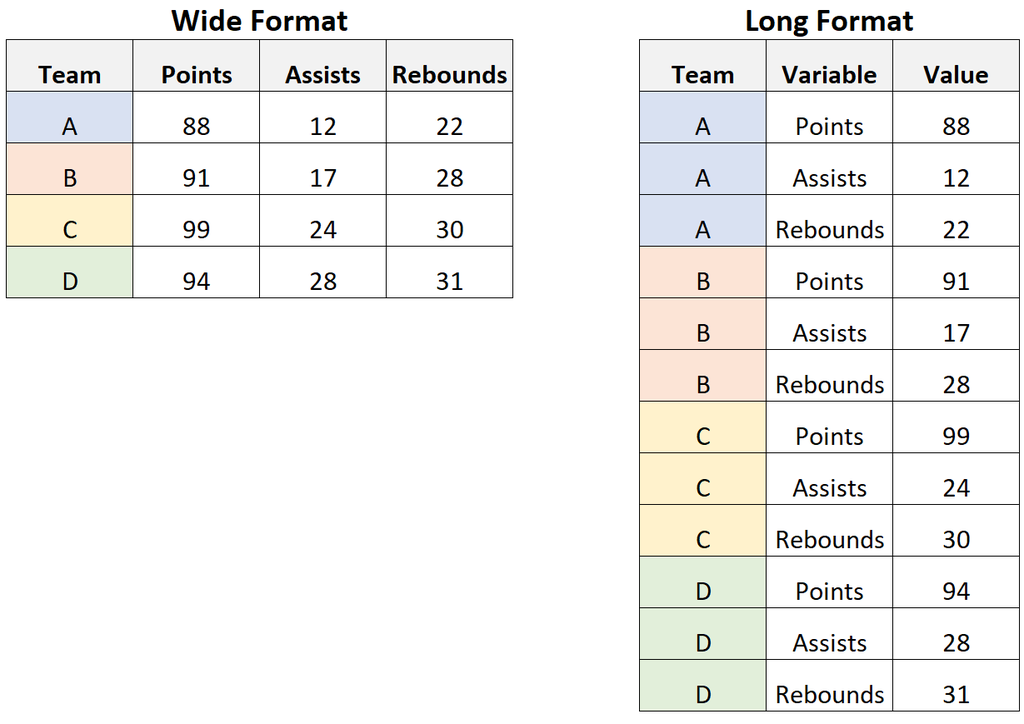

wide and long data

Change it using `pivot_longer()` to change wide to long format, and `pivot_wider()` to change long to wide format.

```r
measurement_txt_long <- pivot_longer(measurement_txt,
                                     cols = c(Baseline, `After Four Weeks`),
                                     names_to = "experiment_time",
                                     values_to = "measurement")
head(measurement_txt_long)     # Get the column together with first six rows (default)
```

```
## # A tibble: 6 × 2
##   experiment_time  measurement
##   <chr>                  <dbl>
## 1 Baseline                353.
## 2 After Four Weeks        309
## 3 Baseline                234.
## 4 After Four Weeks        231.
## 5 Baseline                278.
## 6 After Four Weeks        274.
```

R expects long-format data for many usage (mainly `ggplot()`), just familiarize with it!

Since the statistical summary of all measurements were obtained, why we do not make the hypothetical testing?

# 4 Statistical testing

## 4.1 Check whether the distribution is normal or not

```r
delta_measurement <- measurement_txt$`After Four Weeks` - measurement_txt$Baseline
shapiro.test(delta_measurement)
```

```
##
##  Shapiro-Wilk normality test
##
## data:  delta_measurement
## W = 0.96114, p-value = 0.3312
```

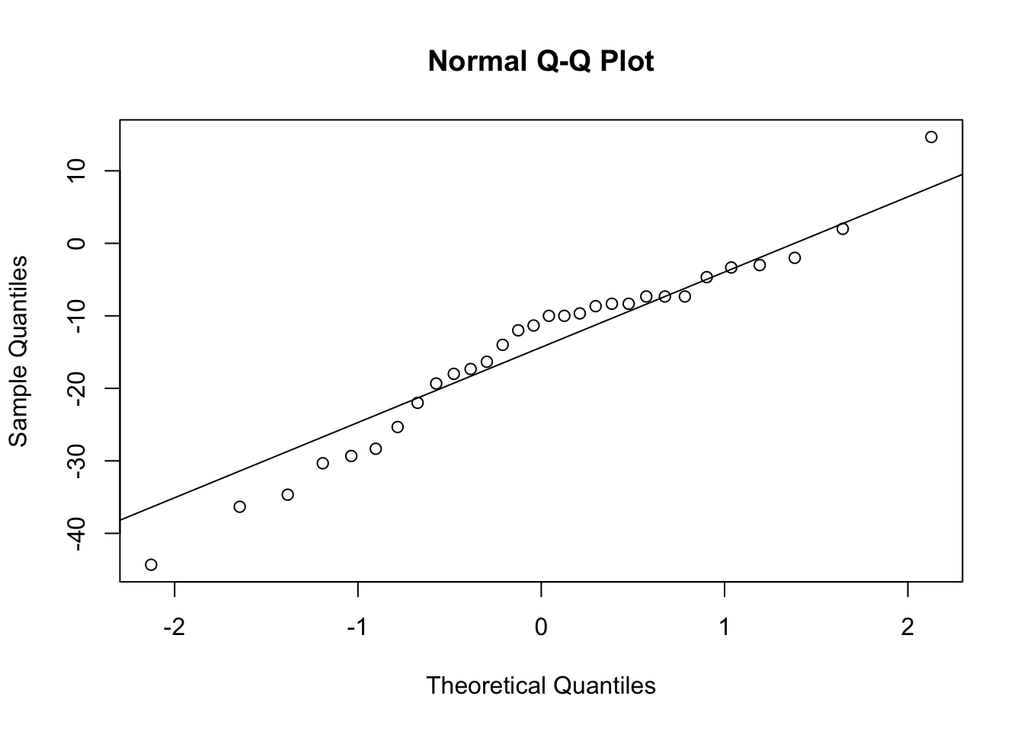

```r
qqnorm(delta_measurement)
qqline(delta_measurement)
```

Since the data is normally distributed based on Shapiro-Wilk test and Q-Q Plot, we will use paired t-test for conducting the hypothetical test.

## 4.2 Calculate the treatment effect

```r
t.test(measurement_txt$Baseline,
       measurement_txt$`After Four Weeks`,
       paired = T)
```

```
##
##  Paired t-test
##
## data:  measurement_txt$Baseline and measurement_txt$`After Four Weeks`
## t = 6.2447, df = 29, p-value = 8.157e-07
## alternative hypothesis: true mean difference is not equal to 0
## 95 percent confidence interval:
##   9.691286 19.130936
## sample estimates:
## mean difference
##        14.41111
```

The experiment between baseline and four weeks after treatment showed the significant effect.

But, the plot will tell the story better than stating facts.

# 5 Plotting the result

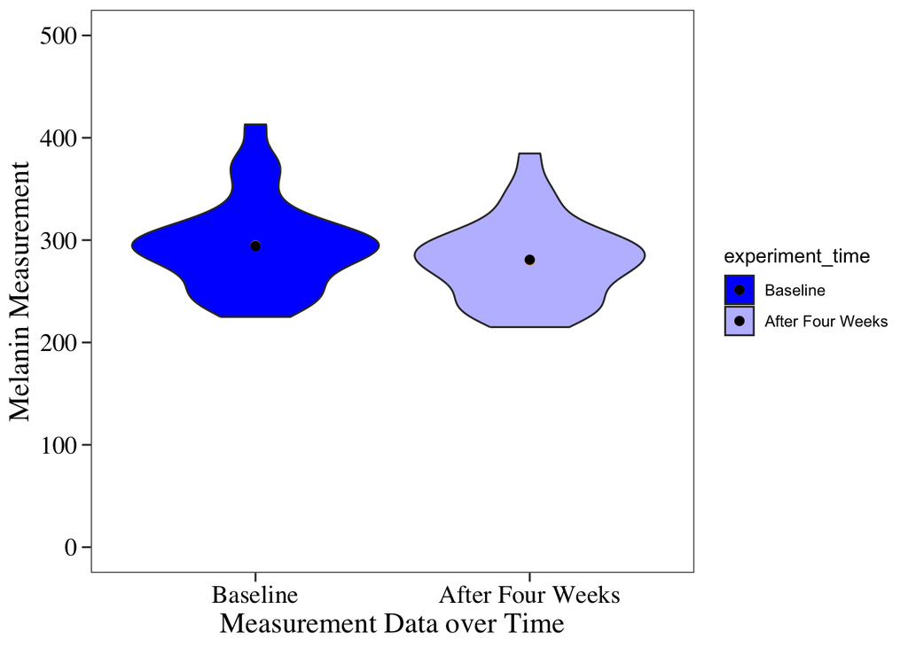

```r
# Making factor to reorder data
measurement_txt_long$experiment_time <- factor(measurement_txt_long$experiment_time,
                                               levels = c("Baseline", "After Four Weeks"))

# Making variable as violin_melanin using ggplot
ggplot(measurement_txt_long,
       aes(x = experiment_time,
           y = measurement,
           fill = experiment_time)) +

# Add violin plot function
  geom_violin() +

# Set color manually
  scale_fill_manual(values=c("#0000FF", "#BFBFFF")) +

# Set y axis in the range of desired values
  ylim(0, 500) +

# Set theme for ggplot2
  theme_bw() +

# Making dot for mean to show it in violin plot for each variables of interest
  stat_summary(fun=mean, geom="point", size=2, color="orange") +

# Making dot for median to show it in violin plot for each variables of interest
  stat_summary(fun=median, geom="point", size=2, color="black") +

# Making label for x-axis
  xlab("Measurement Data over Time") +

# Making label for y-axis
  ylab("Melanin Measurement") +

# Set font size, color and turn off grid in the plot. You may remove this or change it later.
  theme(
    axis.title.x = element_text(color="black", size=16, family = "serif"),
    axis.title.y = element_text(color="black", size=16, family = "serif"),
    panel.grid.major = element_blank(),
    panel.grid.minor = element_blank(),
    axis.text.x.bottom = element_text(color="black", size=14, family = "serif"),
    axis.text.y.left = element_text(color="black", size=14, family = "serif"),
    axis.ticks.length = unit(5, "pt"),
    axis.minor.ticks.length = rel(1)
  )
```